# R Notebook

```r
library(spatstat)
library(maps)
library(maptools)
```

```r
covariate
```

```
       [,1]  [,2]  [,3]  [,4]  [,5]  [,6]  [,7]  [,8]  [,9] [,10] [,11] [,12] [,13]
 [1,] 39.99 36.98 34.45 33.47 32.70 33.51 33.20 34.51 35.13 36.79 37.53 39.87 50.23
 [2,] 34.98 32.39 33.30 34.97 37.12 33.81 32.00 33.25 34.60 36.52 37.00 37.15 41.25
 [3,] 14.05 23.48 30.07 35.90 43.01 41.99 31.16 30.69 28.22 32.69 35.72 42.68 41.70
 [4,] 12.72 23.37 29.13 43.51 43.92 38.63 37.14 35.05 36.46 35.92 34.00 37.00 43.45
 [5,] 12.05 22.11 23.36 39.01 38.29 38.67 36.78 35.02 34.84 36.00 37.46 37.77 36.77
 [6,] 11.39 23.08 30.48 36.05 41.00 34.64 34.40 34.57 32.14 34.14 37.45 35.21 35.35
 [7,] 12.04 22.96 38.17 43.63 39.94 35.18 33.12 32.77 33.10 38.48 40.94 38.50 40.06
 [8,] 12.37 21.86 34.36 39.89 38.37 37.85 32.83 27.86 29.39 41.15 39.51 39.91 37.57
 [9,]  6.63 21.52 26.81 35.45 37.28 36.41 28.20 29.28 29.60 32.49 33.71 33.99 33.81
[10,]  7.06 27.13 30.25 33.11 36.90 37.00 29.82 30.94 27.58 27.58 31.70 30.64 28.59
[11,]  7.51 14.51 27.32 25.90 37.52 37.55 34.07 32.05 32.30 32.97 33.18 30.52 29.44
[12,]  7.70  9.79 21.99 20.96 29.88 38.73 39.50 35.46 33.11 33.67 34.16 31.30 30.90
[13,]  7.06  6.74 14.77 20.83 25.56 30.39 39.59 39.51 33.13 33.37 32.58 34.02 40.55
[14,]  6.52  6.51  7.82 16.70 21.99 26.23 32.33 35.13 32.39 31.51 30.67 31.56 40.40
```

[output cut: 71 more lines]

```r
names(covariates)
```

```
 [1] "lon"       "lat"       "Thick"     "NEAR_DIST" "Area"      "class1"    "class1o"
 [8] "class2"    "MIVER"     "MIVSWD"
```

```r
lon <- covariates$lon
lat <- covariates$lat
```

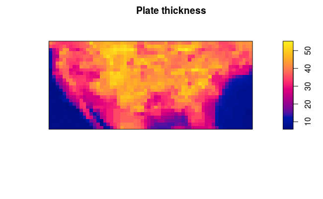

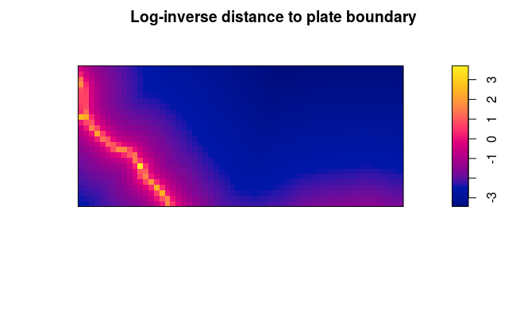

```r
NEAR_DIST <- extractMatrix(covariates$NEAR_DIST, lon, lat)
image.map(log(1/NEAR_DIST), "Log-inverse distance to plate boundary")
```

```r
Area == 0
```

```
logical-valued pixel image
26 x 60 pixel array (ny, nx)
enclosing rectangle: [-125.5, -66.5] x [24.5, 49.5] units
```

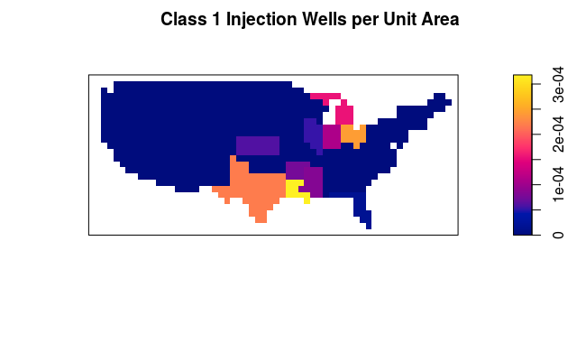

```r
class1 <- extractMatrix(covariates$class1/covariates$Area, lon, lat)
image.map(class1, "Class 1 Injection Wells per Unit Area")
```

```r
class1 <- extractMatrix(covariates$class1/(covariates$Area+1), lon, lat)
```

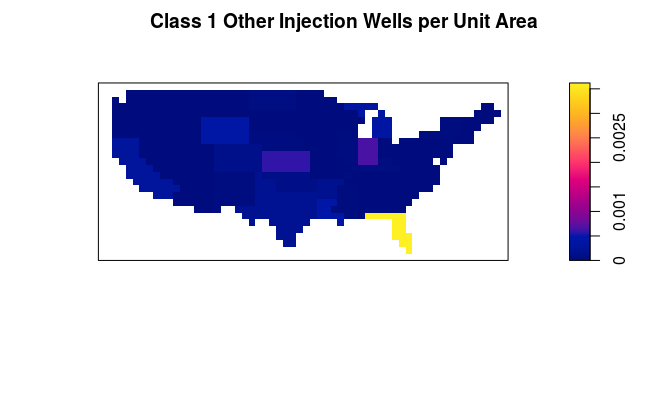

```r
class1o <- extractMatrix(covariates$class1o/covariates$Area, lon, lat)
image.map(class1o, "Class 1 Other Injection Wells per Unit Area")
```

```r
class1o <- extractMatrix(covariates$class1o/(covariates$Area+1), lon, lat)
```

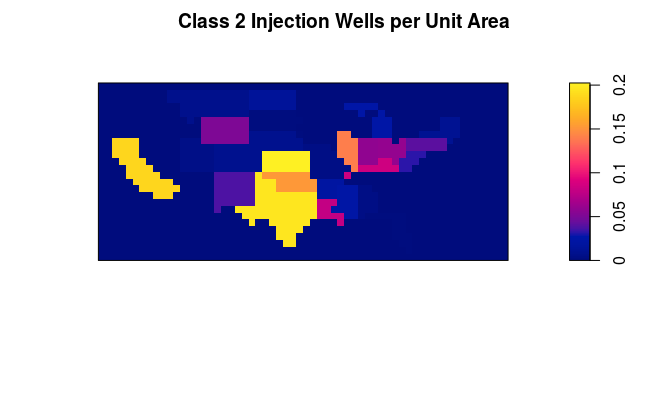

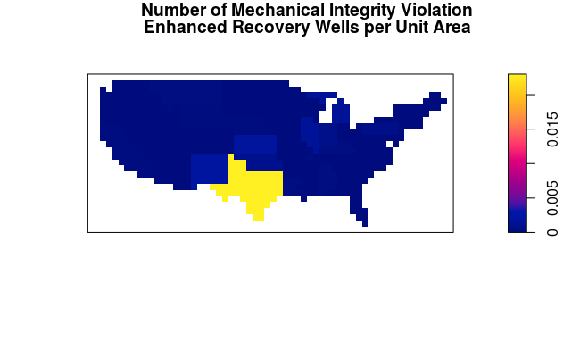

```r
MIVER <- extractMatrix(covariates$MIVER/covariates$Area, lon, lat)
image.map(MIVER, "Number of Mechanical Integrity Violation
Enhanced Recovery Wells per Unit Area")
```

```r
MIVER <- extractMatrix(covariates$MIVER/(covariates$Area+1), lon, lat)
```

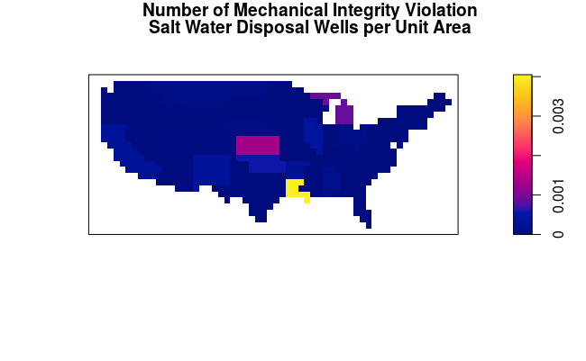

```r
MIVSWD <- extractMatrix(covariates$MIVSWD/covariates$Area, lon, lat)
image.map(MIVSWD, "Number of Mechanical Integrity Violation
Salt Water Disposal Wells per Unit Area")
```

```r
MIVSWD <- extractMatrix(covariates$MIVSWD/(covariates$Area+1), lon, lat)
```

# plot

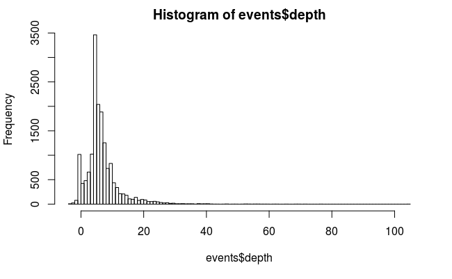

```r
library(ggmap)
```

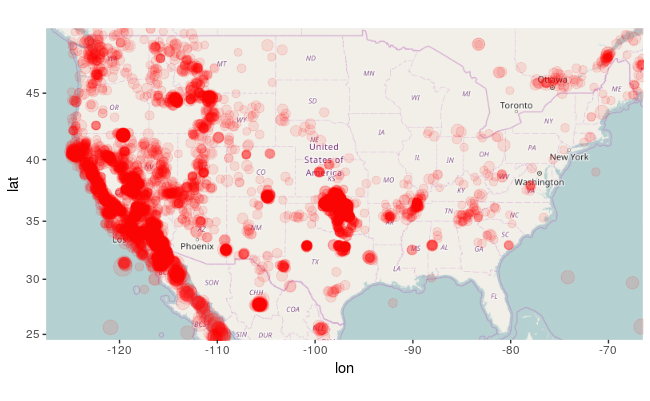

```r
plotevents <- events[events$depth>12,]
ggmap(mapImage) +
  geom_point(data = events, aes(x=longitude, y=latitude),
             color="red", size=events$mag, alpha=0.1)
```

Earthquakes seem to be clustering around west coast, boundary of the North America Plate. Also clustered are the earthquakes near the Intermountain Seismic Belt, which is a terrain actively producing seismic activities.

There is a cluster of earthquakes in the state of Oklahoma, where earthquakes were extremely rare before the year 2005.

We plot the same map using data from 2000 to 2005:

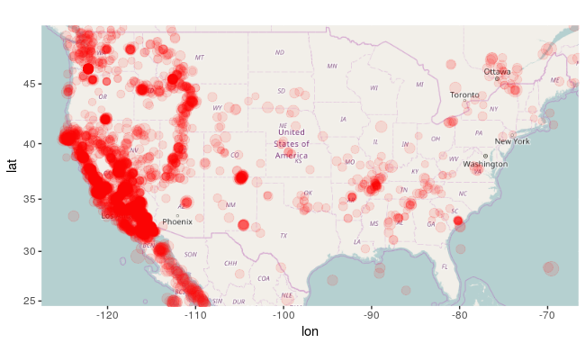

```r
plotevents <- events[events$depth>12,]
ggmap(mapImage) +
  geom_point(data = events2000, aes(x=longitude, y=latitude),
             color="red", size=events2000$mag, alpha=0.1)
```

The cluster along the North America Plate boundary and Intermountain Seismic Belt was present. However, the clustering of events in Oklahoma was non-existant.

## Test for spatial randomness with K and L functions

First create the ppp object.

```r
index <- sample(1:length(events$time), size = 200, replace = F)
statesmap <- map("state", fill = T, plot = F)
state.IDs <- sapply(strsplit(statesmap$names,":"),function(x) x[1])
states.poly <- map2SpatialPolygons(statesmap,IDs=state.IDs,proj4string=CRS("+proj=longlat + datum=wgs84"))
# window <- as.owin(states.poly)
window <- as.owin(c(xmin = -125.5, xmax = -66.5, ymin = 24.5, ymax = 49.5))
# plot(states.poly)
eventsSample.ppp <- ppp(x=events$longitude[index],
                        y=events$latitude[index],
                        window=window)
events.ppp <- ppp(x=events$longitude,
                  y=events$latitude,
                  window=window)
```

Now we can perform the test:

```r
K.events <- Kest(eventsSample.ppp)
envjapK <- envelope(eventsSample.ppp, fun = Kest, nrank = 1, nsim = 99)
envjapL <- envelope(eventsSample.ppp, fun = Lest, nrank = 1, nsim = 99)
```

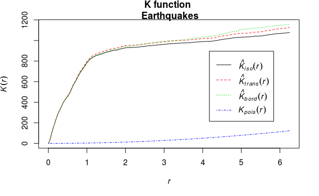

```r
plot(K.events, main="K function \n Earthquakes")
```

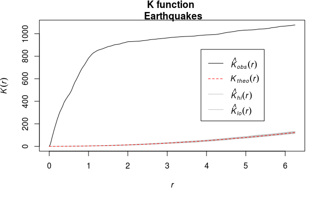

```r
plot(envjapK, main = "K function \n Earthquakes")
```

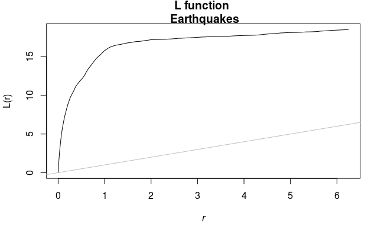

```r
plot(K.events, sqrt(iso/pi) ~ r, ylab = "L(r)",
     main = "L function \n Earthquakes")
abline(a = 0, b = 1 ,col = "grey")
```

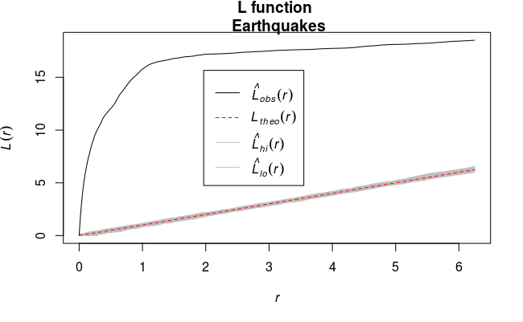

```r
plot(envjapL, main="L function \n Earthquakes")
```

Based on the K- and L-functions, the point pattern exhibits strong evidence of being a clustered point process.

## (c) Perform chi-square tests

### i. H a : the spatial point pattern is not a homogeneous Poisson process

```r
# Two-sided test for CSR based on a null hypothesis of homogenous intensity function
quadrat.test(events.ppp)
```

```
Some expected counts are small; chi^2 approximation may be inaccurate
```

[output not shown]

P-value is extremely small. The test statistic indicates strong evidence for a non-homogeneous Poisson process.

#### ii. Ha : the spatial point pattern is a regular point pattern

```r
# Testing against the alternative hypothesis of a regular point process
quadrat.test(events.ppp, alternative="regular")
```

```
    Chi-squared test of CSR using quadrat counts
    Pearson X2 statistic

data:  events.ppp
X2 = 81174, df = 24, p-value = 1
alternative hypothesis: regular

Quadrats: 5 by 5 grid of tiles
```

P-value is practically 1. The point patter does not behave like a regular point process.

#### iii. H a : the spatial point pattern is a clustered point pattern.

```r
# Testing against the alternative hypothesis of a clustered point process
quadrat.test(events.ppp, alternative="clustered")
```

```
    Chi-squared test of CSR using quadrat counts
    Pearson X2 statistic

data:  events.ppp
X2 = 81174, df = 24, p-value < 2.2e-16
alternative hypothesis: clustered

Quadrats: 5 by 5 grid of tiles
```

It does behave like a clustered point process!

## (d) Monte Carlo test for clustered point process

Simulation test also confirms the finding.

Test is by default conditional upon the observed number of points.

```r
# Testing against the alternative hypothesis of a clustered point process via Monte Carlo simulations
quadrat.test(events.ppp, alternative="clustered", method="M", nsim=4999)
```

```
    Conditional Monte Carlo test of CSR using quadrat counts
    Pearson X2 statistic

data:  events.ppp
X2 = 81174, p-value = 2e-04
alternative hypothesis: clustered

Quadrats: 5 by 5 grid of tiles
```

Again, the p-value is extremely small, indicating evidence that the point pattern is clustered.

## (e) Kernel estimate of intensity function

Let’s esimate a kernel density with optimal bandwidth calculated with `bw.diggle`.

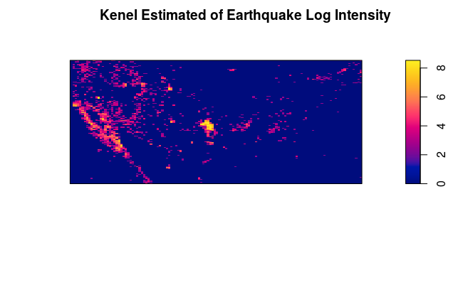

The optimal banwidth for the kernel estimation is 0.0105132 of a degree in terms of longitude of latitude. We have ignored the correction in for curvature in the longitude. The distance between two consecutive longitude lines are 60 nautical miles apart at the euqator, and is around 40 nautical miles at the northernmost point of Contiguous United States. Note, however, that two consequtive latitude lines are always 60 nautical miles apart.

The results of the cross-validated band-width calculates to around 1300 meters, quite small considering the scale of influence an earthquake event. While an earthquake shakes buildings dozens of miles from the epicenter, the estimated non-parametric model tells us that the epicenters of the earthquakes show us right next to each other.

A final comment on the kernel method is that the current smoothing model ignores the temporal nature of events. Stronger earthquakes are often followed by aftershocks at the same locations. A more sound method for cross-validation is, instead of holding out folds of events in the observation, to perform psuedo-out-of sample cross-validation in a sequential manner over time.

## (f) Fit a log-Gaussian Cox process model

```r
u.logcp <- lgcp.estK(events.ppp, c(sigma2=7, alpha=1))
```

```
number of data points exceeds 3000 - computing border correction estimate only
```

```r
u.logcp
```

```
Minimum contrast fit (object of class “minconfit”)
Model: log-Gaussian Cox process
     Covariance model: exponential
Fitted by matching theoretical K function to Kest(events.ppp)

Internal parameters fitted by minimum contrast ($par):
  sigma2    alpha
5.728805 1.800747

Fitted covariance parameters:
     var    scale
5.728805 1.800747

Converged successfully after 63 function evaluations

Starting values of parameters:
sigma2  alpha
     7      1
Domain of integration: [ 0 , 5.372 ]
Exponents: p= 2, q= 0.25
```

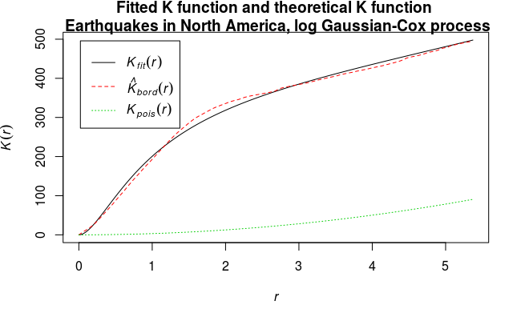

```r
plot(u.logcp,main="Fitted K function and theoretical K function \n Earthquakes in North America, log Gaussian-Cox process")
```

## (g) Fit a Mátern cluster point process model

```
number of data points exceeds 3000 - computing border correction estimate only
```

```
Minimum contrast fit (object of class “minconfit”)
Model: Matern Cluster process
Fitted by matching theoretical K function to Kest(events.ppp)

Internal parameters fitted by minimum contrast ($par):
      kappa           R
0.002815664 0.957528333

Fitted cluster parameters:
      kappa       scale
0.002815664 0.957528333

Converged successfully after 87 function evaluations

Starting values of parameters:
kappa     R
0.003 0.200
Domain of integration: [ 0 , 5.372 ]
Exponents: p= 2, q= 0.25
```

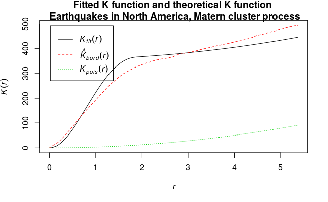

## (h) Fit an inhomogeneous Poisson process with a covariates

```r
fit <- ppm(events.ppp ~ I(log(1/NEAR_DIST)) + Thick)
fit
```

```
Nonstationary Poisson process

Log intensity:  ~I(log(1/NEAR_DIST)) + Thick

Fitted trend coefficients:
        (Intercept) I(log(1/NEAR_DIST))               Thick
         2.25932491          0.36741111          0.02792796

                      Estimate         S.E.   CI95.lo    CI95.hi Ztest     Zval
(Intercept)         2.25932491 0.0238867938 2.2125077 2.30614216   *** 94.58469
I(log(1/NEAR_DIST)) 0.36741111 0.0069166943 0.3538546 0.38096758   *** 53.11947
Thick               0.02792796 0.0007625442 0.0264334 0.02942252   *** 36.62471
```

```r
fit <- ppm(events.ppp ~ I(log((1/NEAR_DIST))) + class1o + class2  + MIVSWD)
fit
```

```
Nonstationary Poisson process

Log intensity:  ~I(log((1/NEAR_DIST))) + class1o + class2 + MIVSWD

Fitted trend coefficients:
          (Intercept) I(log((1/NEAR_DIST)))               class1o                class2
            1.9058191             0.2071208           413.5729862            11.3990267
               MIVSWD
          633.1407350

                         Estimate         S.E.    CI95.lo     CI95.hi Ztest      Zval
(Intercept)             1.9058191  0.018453374   1.869651   1.9419871   *** 103.27754
I(log((1/NEAR_DIST)))   0.2071208  0.006353619   0.194668   0.2195737   ***  32.59887
class1o               413.5729862 16.323546120 381.579424 445.5665487   ***  25.33598
class2                 11.3990267  0.091866184  11.218972  11.5790811   *** 124.08295
MIVSWD                633.1407350  7.371439902 618.692978 647.5884917   ***  85.89105
```